# Red Wine Properties by Micah Shanks

# Univariate Analysis

### What is the structure of your dataset?

There are 1599 wines in the dataset with 13 variables. One variable, X, assigns the wine a number. Quality is a rating, with a minimum of 3 and max of 8 in this dataset (rated on a scale of 0-10, very bad - very excellent). The other 11 variables are chemical properties of the wine.

### What is/are the main feature(s) of interest in your dataset?

I think the main variable of interest in the dataset is quality. The question of interest is finding if any of the chemical properties can be used as strong predictors of the quality of a wine. Because the taste of wine is complex, and a balance of properties is important, I assume I will be looking for a combination of properties that affect quality. My initial interest is in fixed acidity, residual sugar, and alcohol.

### What other features in the dataset do you think will help support your

### investigation into your feature(s) of interest?

Since most wines fall into quality ratings of 5 and 6 and thus we could call these average, it is possible that cutting the data set into low ratings (3/4) and high ratings (7/8) could be a way to look for properties that stand out.

### Did you create any new variables from existing variables in the dataset?

Bouncing off the idea above I created a variable that groups the ratings in low, average, and high.

### Of the features you investigated, were there any unusual distributions?

### Did you perform any operations on the data to tidy, adjust, or change

### the form of the data? If so, why did you do this?

I ran a few correlation test on variables that I thought might be correlated with the quality rating of wine. I found alcohol to have the highest correlation at .47. Surprisingly, residual sugar has effectively no correlation to the quality ratings of wine. Volatile acidity is negatively correlated with quality at a value of -0.39. Some quick research showed me that excessive volatile acids are associated with unpleasing aromos and poor taste. I also found that acids are an important part of the overall character of wine so I want to further explore citric acid which shows a correlation with quality of .22. I also found it interesting that sulphates produced a correlation of .25 since to my understanding this is a perservative used to stop the fermentation process.

### Below I produced the Pearson product-moment correlation coefficient test

### among variables of interest and produced a table as well across all variables

### of interest.

```
##
##  Pearson's product-moment correlation
##
## data:  as.numeric(wine$quality) and wine$fixed.acidity
## t = 4.996, df = 1597, p-value = 6.496e-07
## alternative hypothesis: true correlation is not equal to 0
## 95 percent confidence interval:
##  0.07548957 0.17202667
## sample estimates:
##       cor
## 0.1240516
```

```
##
##  Pearson's product-moment correlation
##
## data:  as.numeric(wine$quality) and wine$volatile.acidity
## t = -16.954, df = 1597, p-value < 2.2e-16
## alternative hypothesis: true correlation is not equal to 0
## 95 percent confidence interval:
##  -0.4313210 -0.3482032
## sample estimates:
##        cor
## -0.3905578
```

```
##
##  Pearson's product-moment correlation
##
## data:  as.numeric(wine$quality) and wine$citric.acid
## t = 9.2875, df = 1597, p-value < 2.2e-16
## alternative hypothesis: true correlation is not equal to 0
## 95 percent confidence interval:
##  0.1793415 0.2723711
## sample estimates:
##       cor
## 0.2263725
```

```
##
##  Pearson's product-moment correlation
##
## data:  as.numeric(wine$quality) and wine$residual.sugar
## t = 0.5488, df = 1597, p-value = 0.5832
## alternative hypothesis: true correlation is not equal to 0
## 95 percent confidence interval:
##  -0.03531327  0.06271056
## sample estimates:
##        cor
## 0.01373164
```

```
##
##  Pearson's product-moment correlation
##
## data:  as.numeric(wine$quality) and wine$alcohol
## t = 21.639, df = 1597, p-value < 2.2e-16
## alternative hypothesis: true correlation is not equal to 0
## 95 percent confidence interval:
##  0.4373540 0.5132081
## sample estimates:
##       cor
## 0.4761663
```

```
##
##  Pearson's product-moment correlation
##
## data:  as.numeric(wine$quality) and wine$sulphates
## t = 10.38, df = 1597, p-value < 2.2e-16
## alternative hypothesis: true correlation is not equal to 0
## 95 percent confidence interval:
##  0.2049011 0.2967610
## sample estimates:
##       cor
## 0.2513971
```

```
##
## Two-Step Estimates
##
## Correlations/Type of Correlation:
##                  quality fixed.acidity volatile.acidity citric.acid
## quality                1       Pearson          Pearson     Pearson
## fixed.acidity     0.1241             1          Pearson     Pearson
## volatile.acidity -0.3906       -0.2561                1     Pearson
## citric.acid       0.2264        0.6717          -0.5525           1
## residual.sugar   0.01373        0.1148         0.001918      0.1436
## alcohol           0.4762      -0.06167          -0.2023      0.1099
## sulphates         0.2514         0.183           -0.261      0.3128
##                  residual.sugar alcohol sulphates
## quality                 Pearson Pearson   Pearson
## fixed.acidity           Pearson Pearson   Pearson
## volatile.acidity        Pearson Pearson   Pearson
## citric.acid             Pearson Pearson   Pearson
## residual.sugar                1 Pearson   Pearson
## alcohol                 0.04208       1   Pearson
## sulphates              0.005527 0.09359         1
##
## Standard Errors:
##                  quality fixed.acidity volatile.acidity citric.acid
## quality
## fixed.acidity    0.02463
## volatile.acidity  0.0212       0.02338
## citric.acid      0.02373       0.01374          0.01739
## residual.sugar   0.02501       0.02469          0.02502      0.0245
## alcohol          0.01935       0.02492          0.02399     0.02471
## sulphates        0.02344       0.02418          0.02331     0.02257
##                  residual.sugar alcohol
## quality
## fixed.acidity
## volatile.acidity
## citric.acid
## residual.sugar
## alcohol                 0.02497
## sulphates               0.02501  0.0248
##
## n = 1599
##
## P-values for Tests of Bivariate Normality:
##                     quality fixed.acidity volatile.acidity citric.acid
## quality
## fixed.acidity     1.25e-284
## volatile.acidity 1.042e-274     3.003e-24
## citric.acid      1.375e-286     2.027e-31        1.032e-28
## residual.sugar            0             0       3.574e-298   1.07e-309
## alcohol          1.587e-273     5.201e-49        5.487e-22   3.231e-36
## sulphates        4.741e-299     2.298e-49         1.88e-31   6.469e-40
##                         residual.sugar   alcohol
## quality
## fixed.acidity
## volatile.acidity
## citric.acid
## residual.sugar
## alcohol          2.43300000000155e-312
## sulphates        4.10074486048235e-322 4.959e-50
```

```
Correlation matrix, not including in final report

theme_set(them_minimal(20))

set.seed(500)
wine_subset <- wine[, c(2:13)]
names(wine_subset)
ggpairs(wine_subset[sample.int(nrow(wine_subset), 1000),])
```

# Bivariate Plots Section

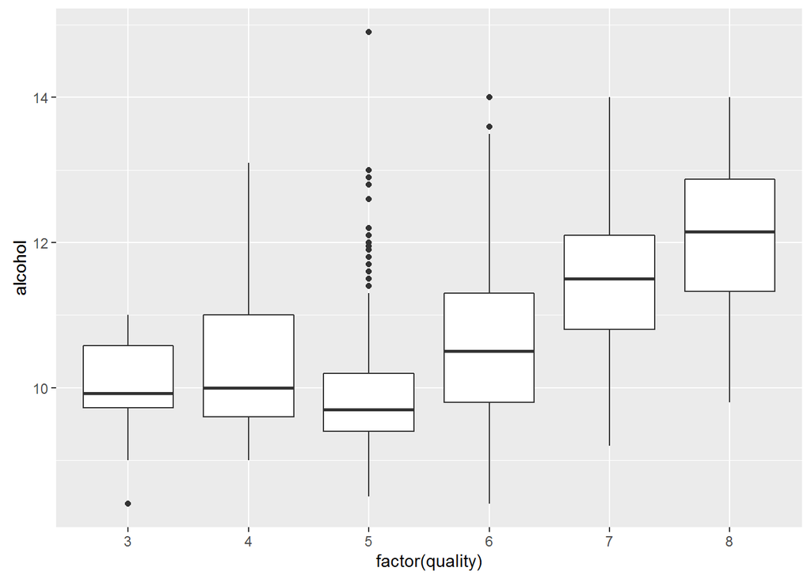

I first ran a scatterplot on quality vs. alcohol, but I found a boxplot is a more useful visualization of the relationship. It is clear that higher rated wines have more alcohol.

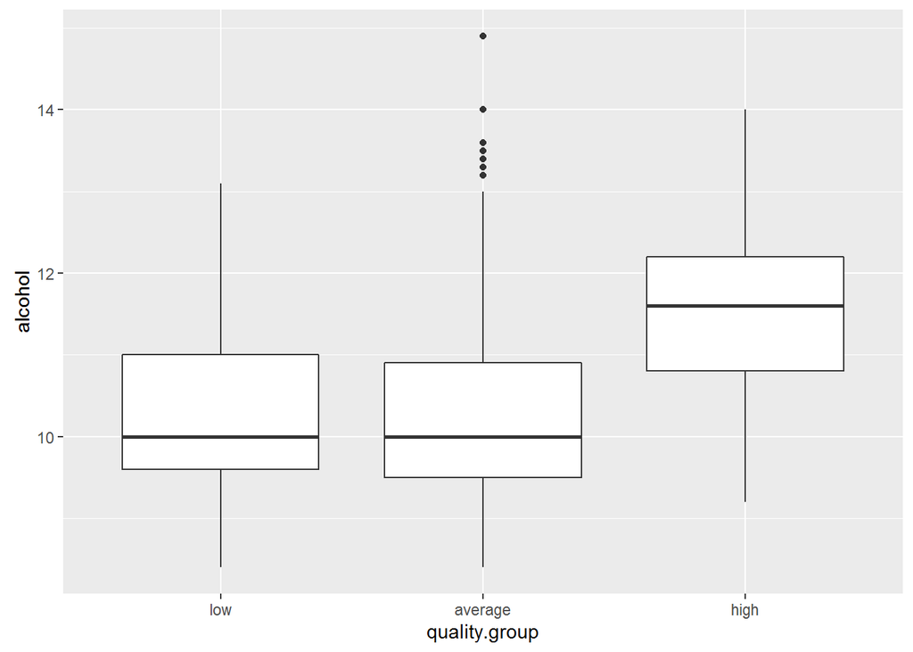

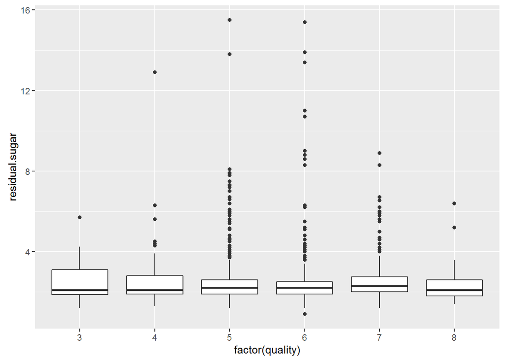

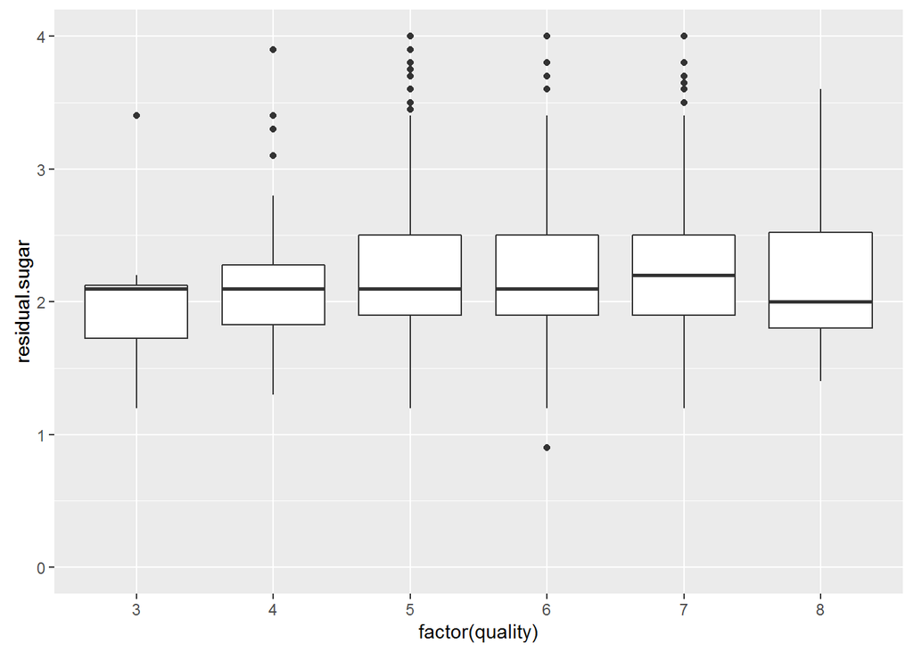

Removing the outliers gives a clearer picture of the distributions and shows that the medians are similar across all quality rating.

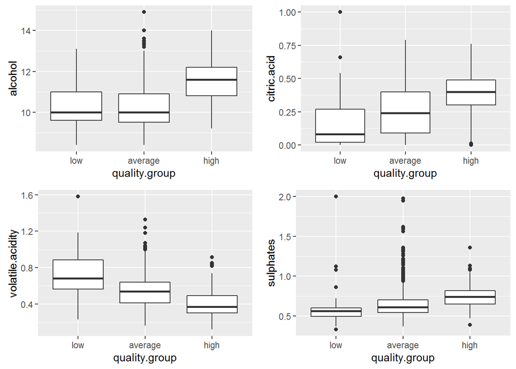

This is a group of boxplots of the four variables that I am most interested in thus far, based on correlations. They all visualize notable trends.

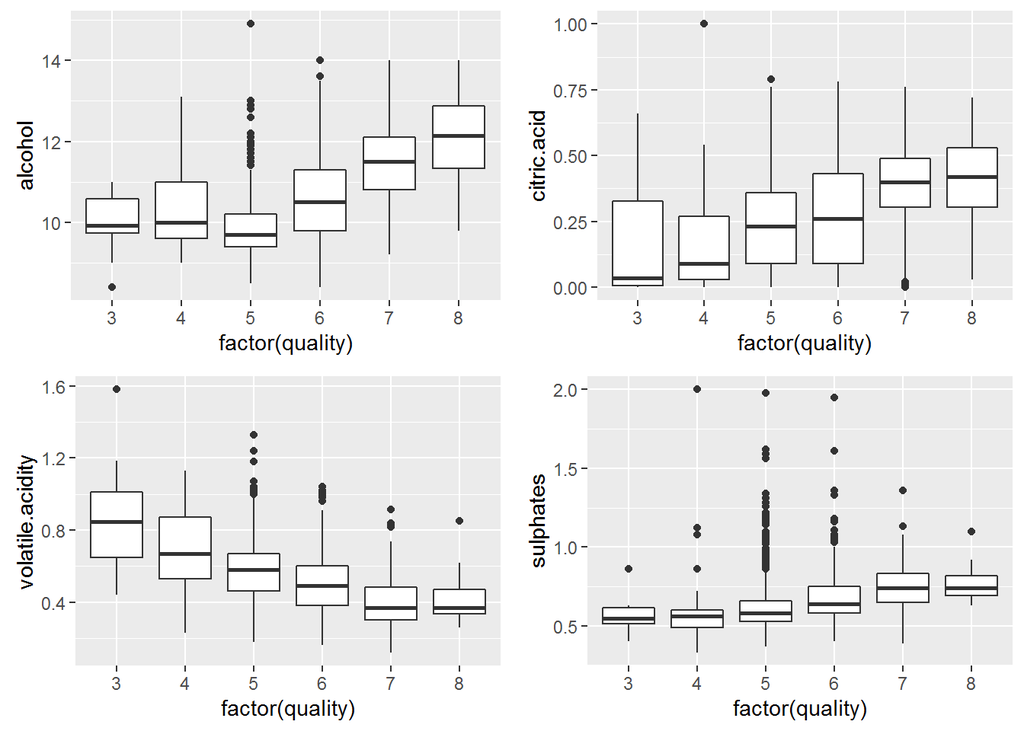

Here is the same group of plots, except using the original ratings. I think for the most part, my grouped ratings tell a story that is easier to see. It is interesting that the clearest trend that emerges from these plots is the relationship betweeen volatile acidity and quality.

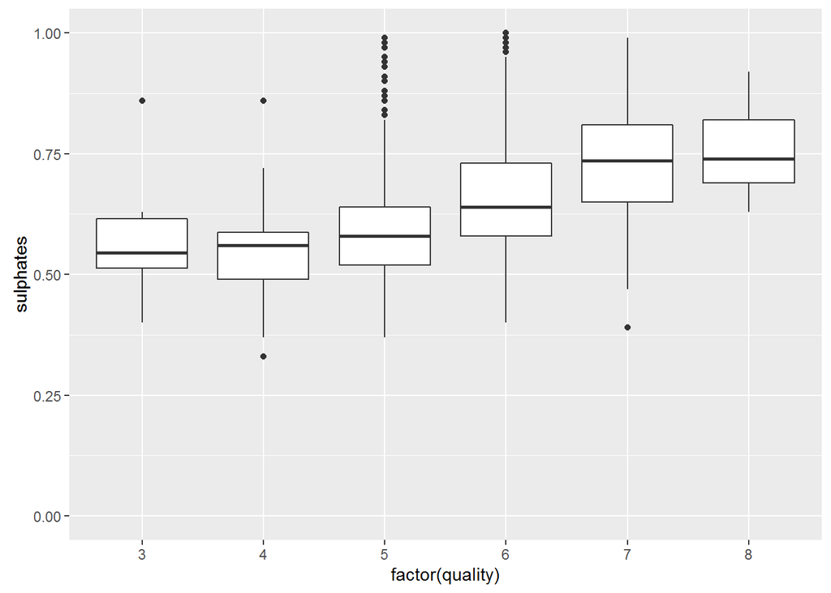

Because of the large amount of outliers, truncating the y-axis gives a clearer picture of the trend between suplphates and quality.

# Bivariate Analysis

### Talk about some of the relationships you observed in this part of the

### investigation. How did the feature(s) of interest vary with other features

### Did you observe any interesting relationships between the other features

### (not the main feature(s) of interest)?

A bivariate analysis developed my features of interest. Alcohol made the list with it’s strong effect on quality. where I originally thought fixed.acid would be an interesting factor (based soley on my lack of expertise), I now see that citric acid is a better predictor of quality. I found that sugar does not have the effect I thought it might, however volatile acidity and sulphate levels proved to be chemical properties that seem to have an effect on quality ratings in this dataset.

### What was the strongest relationship you found?

Alcohol is the strongest relationship I found.

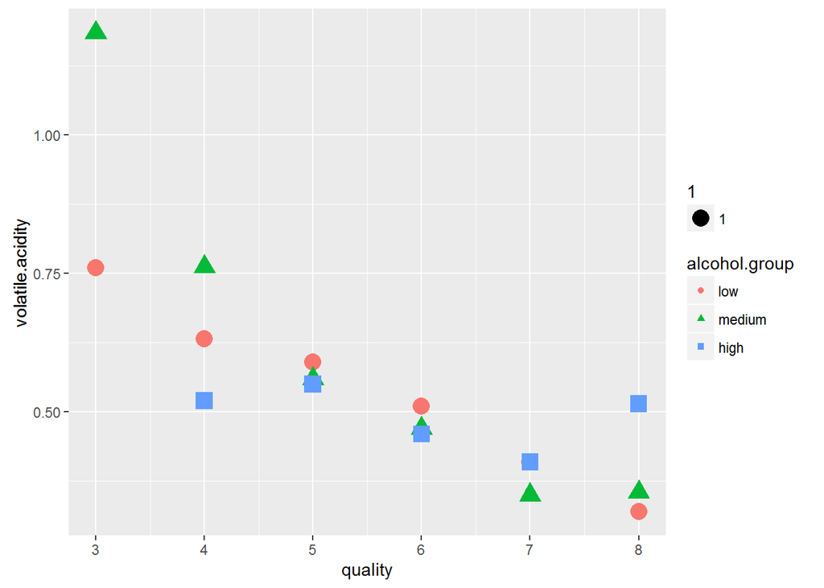

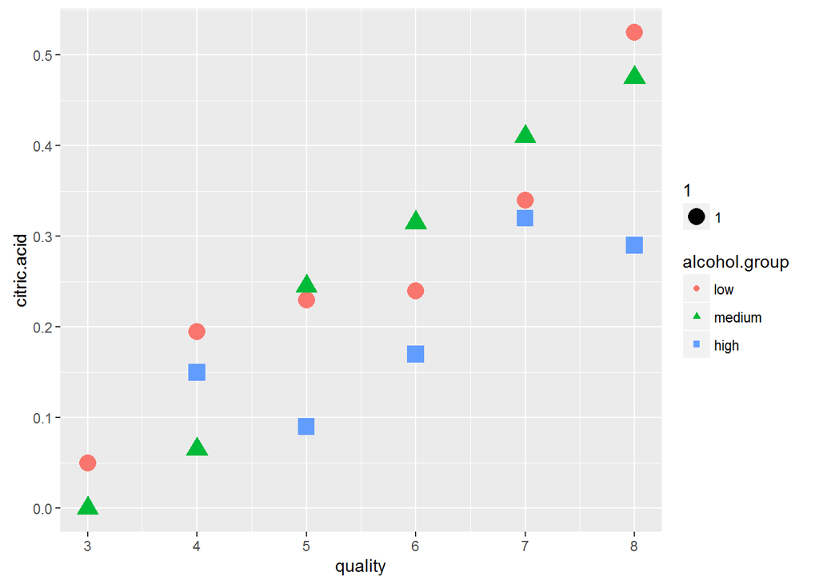

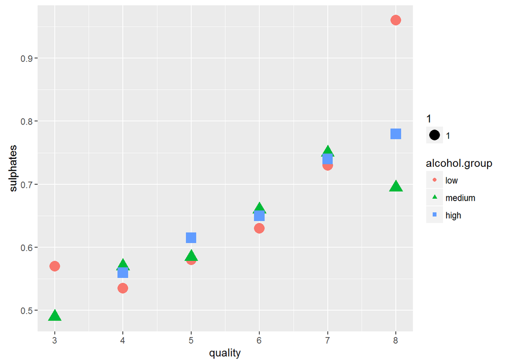

```
##
##  Pearson's product-moment correlation
##
## data:  wine$alcohol and wine$sulphates
## t = 3.7568, df = 1597, p-value = 0.0001783
## alternative hypothesis: true correlation is not equal to 0
## 95 percent confidence interval:
##  0.04477906 0.14196454
## sample estimates:
##        cor
## 0.09359475
```

This chart shows the median sulphate levels across quality ratings by alcohol groups. The grouping among quality ratings 4-7 pops out first. There appears to be a linear relationship and the alcohol groups are have similar sulphate measurements across the ratings. The lowest and highest ratings (3-8), have more variance, especially at rating 8.

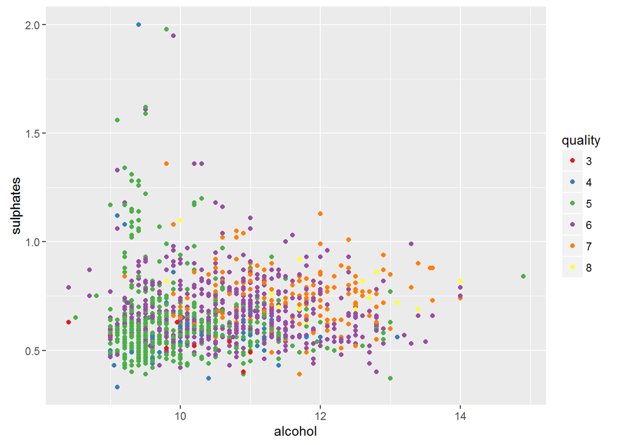

This chart plots each wine based on their alcohol and sulphate levels, colored by quality rating. Since there isn’t a lot of data on the highest and lowest ratings, it is difficult to see any trends among those ratings. Of the lower quality wines, I can see points despersed across alcohol levels, at lower sulphate measurements. There is a grouping of those wines with quality level 5 trending toward lower sulphate and alcohol levels. It seems that wines rated at quality 6 and 7 tend to have higher alcohol levels, yet are dispersed across sulphate levels, mostly within the range of .5 and 1.0.

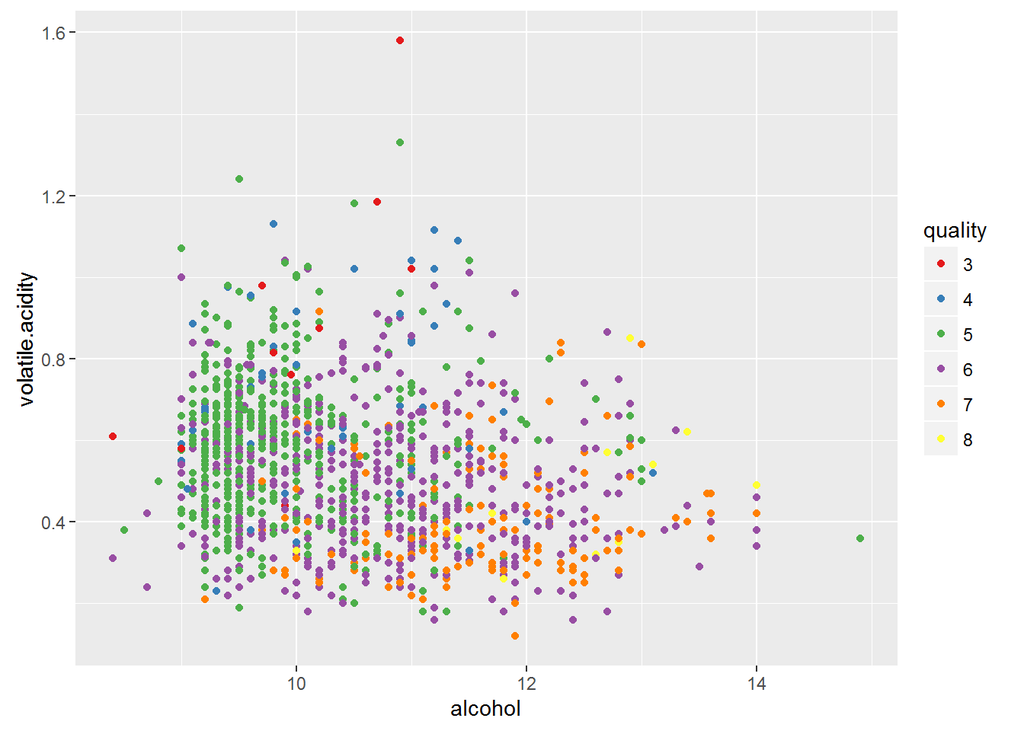

Here I changed the y axis to volatile acidity. I would have expected to see less dispersion across volatile acidity here across quality ratings. Again those wines rated 5 are tending toward lower abv. I do see lower quality wines plotted at higher volatile acidity and the highest quality wines plotted at lower volatile acidity, however average rated wines show a lot of variance among volatile acidity measurements.

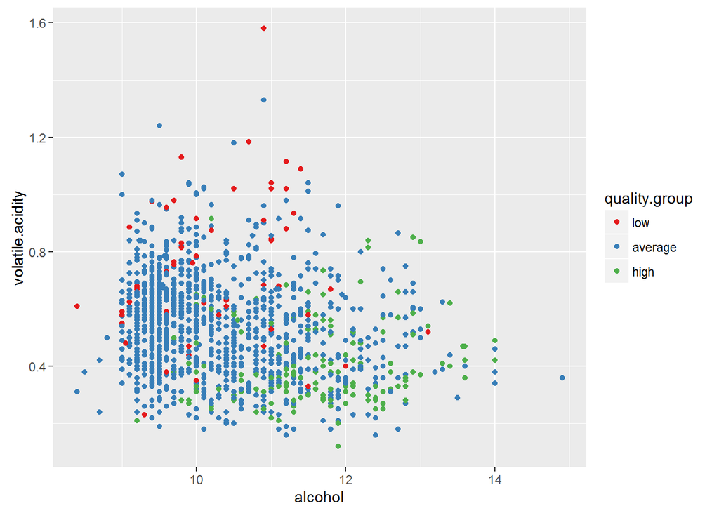

When using the grouped quality ratings variable, a trend is easier to see. Higher rated wines dispersed across all abv levels, tend to lower volatile acidity. Average tend to have lower alcohol levels and have more variance across volatile acidity. I am surprised that I am not seeing low quality wines grouped together.

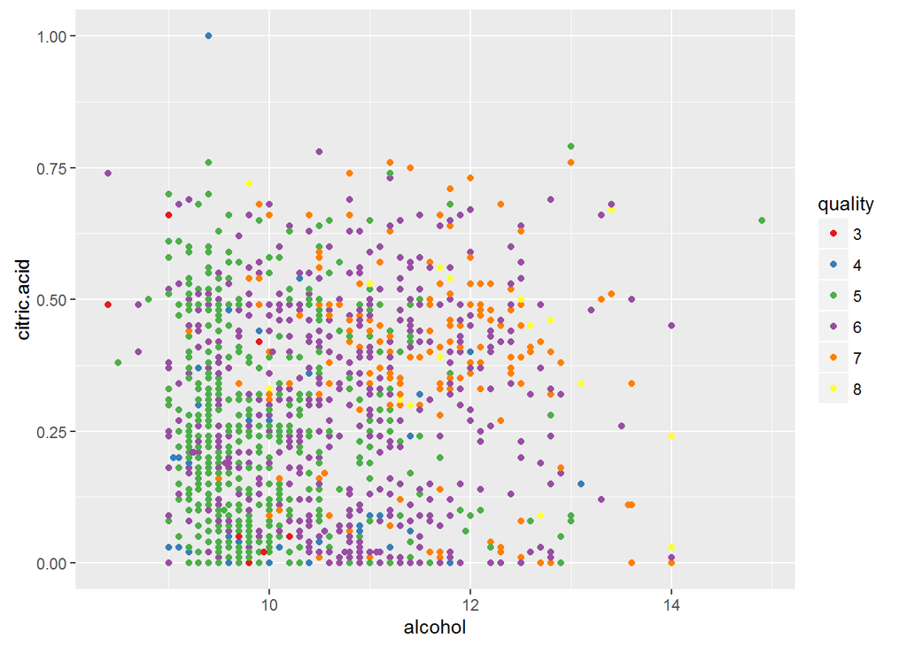

This chart with citric.acid on the y scale shows a lot of dispersion across citric acid levels, yet again alcohol is grouped lower within a quality rating of 5. By now we can start to see that most wines rated 5 in this data set, regardless of other factors will mostly have alcohol levels inbetween 8-10 and those rated 7 or 8 will mostly have abv of 10+.

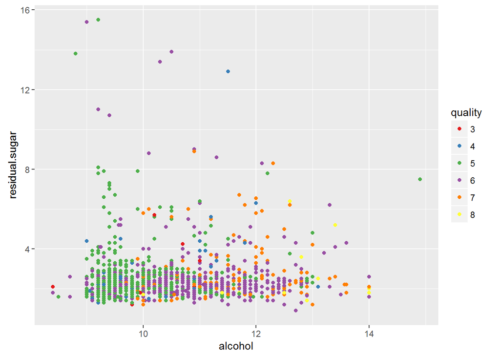

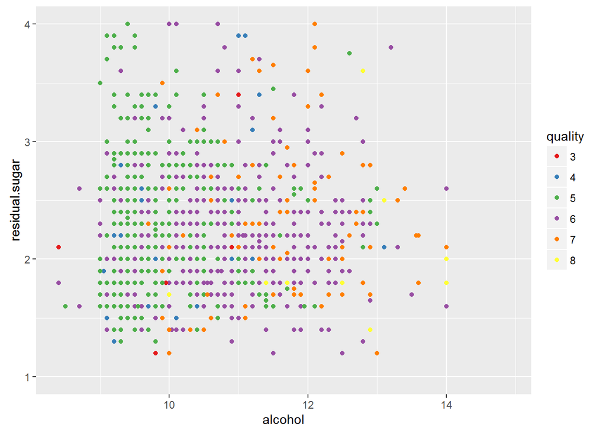

I lost interest in residual sugar as a predictor early in my analysis, but I wanted to see it next to alcohol, grouped by quality. I assume the wines with higher residual sugar levels are desert wines or wines known for their sweeter qualities. Zoomed in on where most of the data lies, there isn’t much of a trend to see other than reconfirming what has been seen with quality rating trends in previous plots.

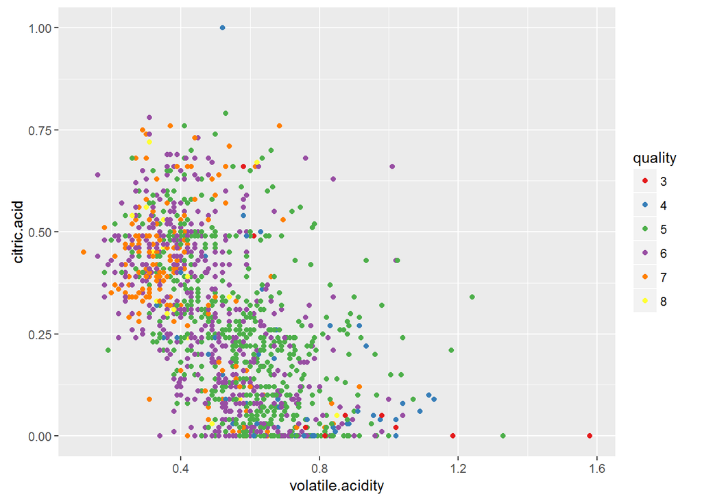

Intuitively, when we plot two measurements that deal with acidity, the closest thing to a linear relationship see among this run of plots emerges, but with a lot of variance. There are groupings among quality ratings 5 and 7 that can be easily seen.

# Multivariate Analysis

### Talk about some of the relationships you observed in this part of the

### investigation. Were there features that strengthened each other in terms

### of looking at your feature(s) of interest?

### Were there any interesting or surprising interactions between features?

As alcohol seems to have the most significant impact on quality ratings, I split it up into 3 groups: low, medium, and high alohol content so I could see how these groups interacted with other variables of interest.

Through these plots I noticed that of those wines in the group with high alcohol, none of these wines received a rating of 3.

I also plotted citric acid among the 3 groups. This plot seems to show a relationship with higher ratings and higher citric acid levels across all groups. Again though, the high alcohol group was least affected by citric acid levels vs quality ratings. Other than at quality rating 4, the high alcohol group had less citric acid at every rating (5-8) vs the low and medium groups.

Next I plotted suplphate levels by quality v quality rating by alcohol groups. The relationship was very similar across all quality ratings other than 8. At a rating of 8, it seems that wines with lower alcohol had higher levels of suplphates.

Throughout the scatterplots, the strongest trend visualized was that average rated wines tend to have lower alcohol and higher rated wines have higher alcohol levels.

### OPTIONAL: Did you create any models with your dataset?

### Discuss the strengths and limitations of your model.

Because the relationship between quality and alcohol are plotted within 6 quality ratings (3-8), I found it difficult to see if the relationship is linear, although they don’t look far from it.

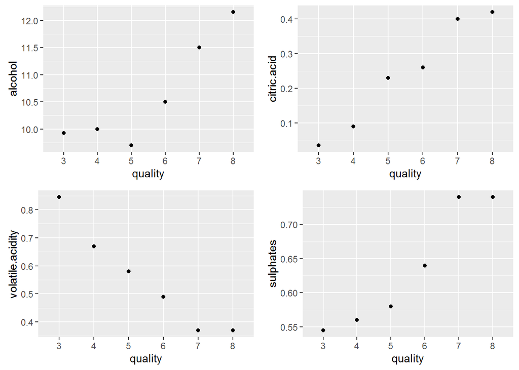

In this group of charts, the points represent the median alcohol level among each quality rating. There are relationships that seem to break out among quality ratings, for example among quality ratings 6-8 within alcohol measurements. Volatile acidity looks to have a linear relationship across ratings and with it’s Pearson correlation coefficient of -.39 might be a moderate predictor in a linear model.

I attempted a simple model that test the relationship between quality and 4 other variables. Past alcohol and volatile acidity, the model doesn’t appear to predict much. With an r-squared value of .3, I do not see this model as dependably predictive.

```
##
## Calls:
## m1: lm(formula = as.numeric(quality) ~ alcohol, data = wine)
## m2: lm(formula = as.numeric(quality) ~ alcohol, data = wine)
## m3: lm(formula = as.numeric(quality) ~ alcohol + volatile.acidity,
##     data = wine)
## m4: lm(formula = as.numeric(quality) ~ alcohol + volatile.acidity +
##     citric.acid, data = wine)
## m5: lm(formula = as.numeric(quality) ~ alcohol + volatile.acidity +
##     citric.acid + sulphates, data = wine)
##
## ===========================================================================
##                        m1         m2         m3         m4         m5
## ---------------------------------------------------------------------------
##   (Intercept)       -0.125     -0.125      1.095***   1.055***   0.646**
##                     (0.175)    (0.175)    (0.184)    (0.194)    (0.201)
##   alcohol            0.361***   0.361***   0.314***   0.314***   0.309***
##                     (0.017)    (0.017)    (0.016)    (0.016)    (0.016)
##   volatile.acidity                        -1.384***  -1.343***  -1.265***
##                                           (0.095)    (0.114)    (0.113)
##   citric.acid                                         0.068     -0.079
##                                                      (0.103)    (0.104)
##   sulphates                                                      0.696***
##                                                                 (0.103)
## ---------------------------------------------------------------------------
##   R-squared              0.2        0.2        0.3        0.3        0.3
##   adj. R-squared         0.2        0.2        0.3        0.3        0.3
##   sigma                  0.7        0.7        0.7        0.7        0.7
##   F                    468.3      468.3      370.4      247.0      201.8
##   p                      0.0        0.0        0.0        0.0        0.0
##   Log-likelihood     -1721.1    -1721.1    -1621.8    -1621.6    -1599.1
##   Deviance             805.9      805.9      711.8      711.6      691.9
##   AIC                 3448.1     3448.1     3251.6     3253.2     3210.2
##   BIC                 3464.2     3464.2     3273.1     3280.1     3242.4
##   N                   1599       1599       1599       1599       1599
## ===========================================================================
```

# Final Plots and Summary

### Plot One

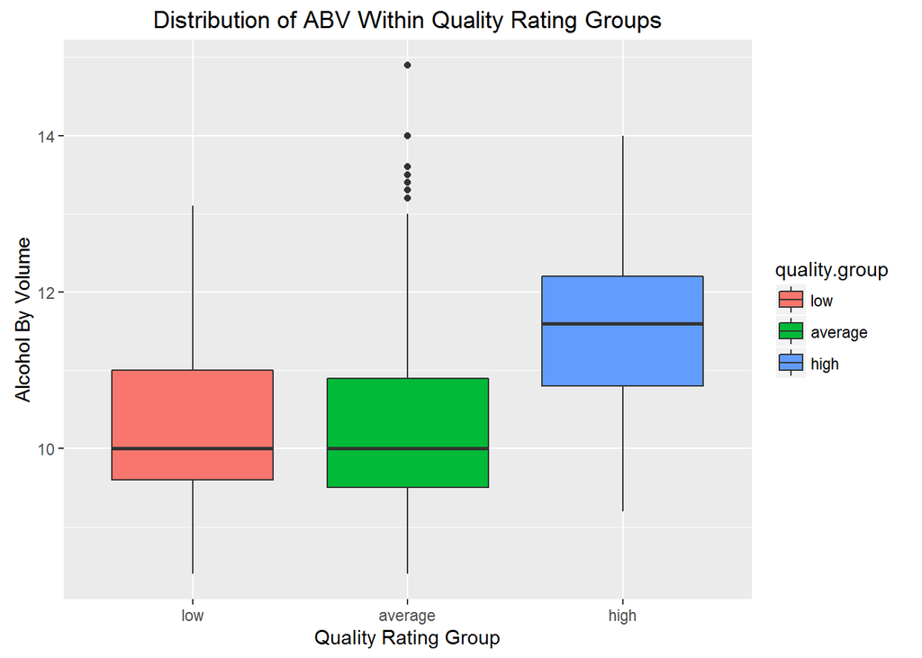

### Description One This boxplot shows a clear difference between the three quality groups (low, average, high). Those wines have been rated a 7 or 8 in quality ratings have a much higher mean of abv. There are some wines in the average group that have high alcohol, shown as outliers on the boxplot, however this vizualization shows that most wines that have a higher rating will have more alcohol than those that are rated as low or average.

### Plot Two

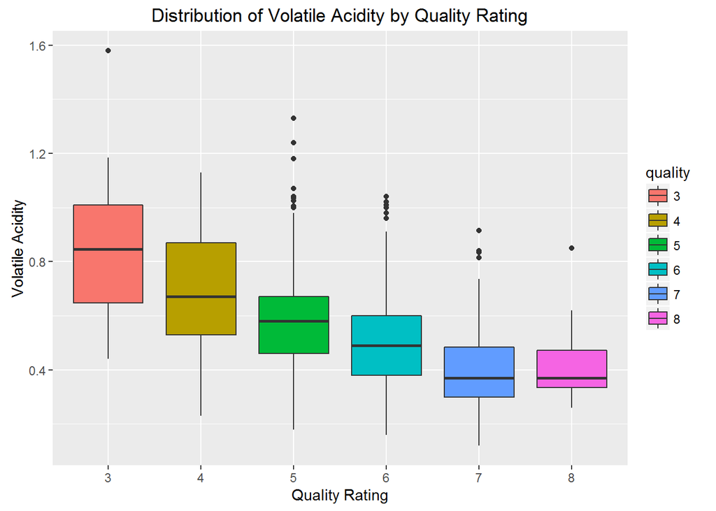

### Description Two

This boxplot is a good respresentation of the negative correlation that volatile acidity has with quality rating. It is clear that as lower rated wines have higher levels of volatile acidity, while higher rated wines have lower volatile acidity. Those wines rated 7 or 8 have similar levels. It can also be seen that among lower quality ratings, there more of a range among volatile acidity measurements, but as quality ratings increase, the range becomes more compact, with less outliers as well. If you told me one wine has a volatile acidity of .4 and the another .8, I would tell you I would like to drink the one with .4.

### Plot Three

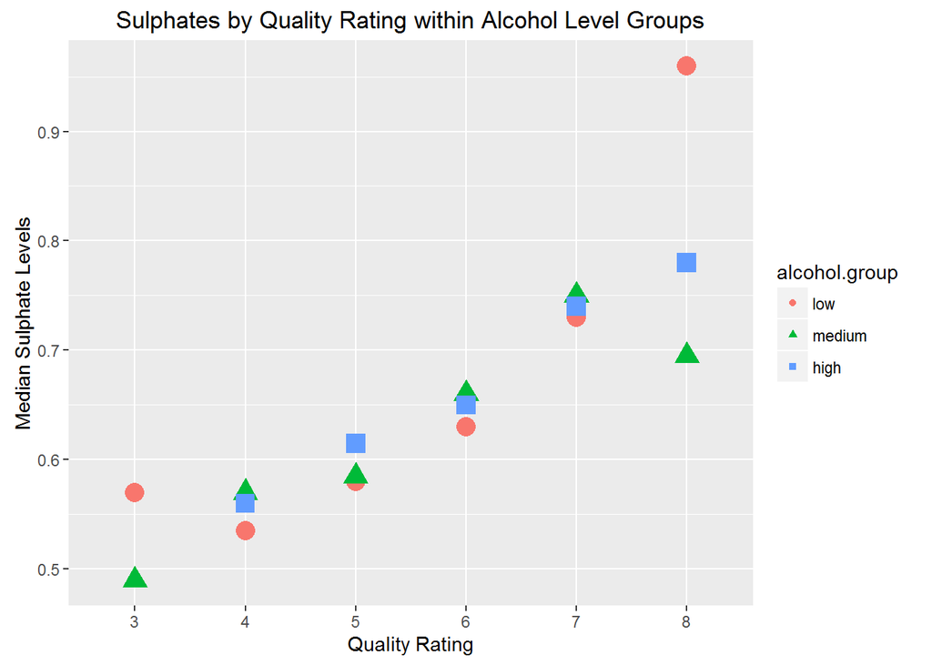

### Description Three

I found this plot interesting because it emerged that sulphate levels are quite consistent across quality ratings among alcohol groups. No matter if a wine has a low, medium, or high abv, among quality ratings of 4-7, wines follow a distinct pattern. Only at the rating of 8 is there divergence.

# Reflection

This exercise gave me a better understanding of how trends and variables to explore can emerge through visualization. I was able to use a correlation computation to find out which variables might be worth exploring, however it is the plots that help answer the subtleties of how one variable affects another. I liked the idea of grouping properties of interest in this exercise to help dig deeper into how the the property affected quality ratings. This project did reinforce the importance of running statistical test. I think visualizations of data can be exciting and lead you to believe that a particular variable is affecting another much more than it actually is. I honestly expected even my simple linear model to show higher r-squared values than it did.

If I were going to further explore this group I would want a lot more wines rated low (3 or lower) and high (8 and higher) so I could have more confidence in my findings.

```
##
##   3   4   5   6   7   8
##  10  53 681 638 199  18
```

This data set only has 10 wines rated as a 3 and 18 rated as an 8. That makes a good argument for splitting the quality ratings into 3 groups as I did to draw conclusions, but one could be less confident about drawing conclusions from observations within the wines rated as 3 or 8. Then again, using the groups gives less of a chance to see unique trends that emerge among specific quality ratings.